# Data Visualization for Data Exploration

Edwin Maldonado - `emaldonado1127@floridapoly.com`

### Loading libraries

```r
library("dplyr")
library("ggplot2")
library("tidyverse")
```

### Reading the dataset

```r
vehicle <- read_csv("C:\\Users\\maldo\\OneDrive\\Desktop\\FloridaPoly\\Data vizualization\\dataviz_mini-project_01 Edwin Maldonado\\data\\fuel.csv", col_types = cols())
```

### Checking dataset

```r
head(vehicle)
```

| vehicle_id | year | make | model | class | drive | transmission | transmission_type | engine_index | engine_descriptor | engine_cylinders | engine_displacement | turbocharger | supercharger | fuel_type | fuel_type_1 | fuel_type_2 | city_mpg_ft1 | unrounded_city_mpg_ft1 | city_mpg_ft2 | unrounded_city_mpg_ft2 | city_gasoline_consumption_cd | city_electricity_consumption | city_utility_factor | highway_mpg_ft1 | unrounded_highway_mpg_ft1 | highway_mpg_ft2 | unrounded_highway_mpg_ft2 | highway_gasoline_consumption_cd | highway_electricity_consumption | … |
| --- | --- | --- | --- | --- | --- | --- | --- | --- | --- | --- | --- | --- | --- | --- | --- | --- | --- | --- | --- | --- | --- | --- | --- | --- | --- | --- | --- | --- | --- | --- |
| 26587 | 1984 | Alfa Romeo | GT V6 2.5 | Minicompact Cars | NA | Manual 5-Speed | NA | 9001 | (FFS) | 6 | 2.5 | NA | NA | Regular | Regular Gasoline | NA | 17 | 0 | 0 | 0 | 0 | 0 | 0 | 24 | 0 | 0 | 0 | 0 | 0 | … |
| 27705 | 1984 | Alfa Romeo | GT V6 2.5 | Minicompact Cars | NA | Manual 5-Speed | NA | 9005 | (FFS) CA model | 6 | 2.5 | NA | NA | Regular | Regular Gasoline | NA | 17 | 0 | 0 | 0 | 0 | 0 | 0 | 24 | 0 | 0 | 0 | 0 | 0 | … |
| 26561 | 1984 | Alfa Romeo | Spider Veloce 2000 | Two Seaters | NA | Manual 5-Speed | NA | 9002 | (FFS) | 4 | 2.0 | NA | NA | Regular | Regular Gasoline | NA | 18 | 0 | 0 | 0 | 0 | 0 | 0 | 25 | 0 | 0 | 0 | 0 | 0 | … |
| 27681 | 1984 | Alfa Romeo | Spider Veloce 2000 | Two Seaters | NA | Manual 5-Speed | NA | 9006 | (FFS) CA model | 4 | 2.0 | NA | NA | Regular | Regular Gasoline | NA | 18 | 0 | 0 | 0 | 0 | 0 | 0 | 25 | 0 | 0 | 0 | 0 | 0 | … |
| 27550 | 1984 | AM General | DJ Po Vehicle 2WD | Special Purpose Vehicle 2WD | 2-Wheel Drive | Automatic 3-Speed | NA | 1830 | (FFS) | 4 | 2.5 | NA | NA | Regular | Regular Gasoline | NA | 18 | 0 | 0 | 0 | 0 | 0 | 0 | 17 | 0 | 0 | 0 | 0 | 0 | … |
| 28426 | 1984 | AM General | DJ Po Vehicle 2WD | Special Purpose Vehicle 2WD | 2-Wheel Drive | Automatic 3-Speed | NA | 1880 | (FFS) CA model | 4 | 2.5 | NA | NA | Regular | Regular Gasoline | NA | 18 | 0 | 0 | 0 | 0 | 0 | 0 | 17 | 0 | 0 | 0 | 0 | 0 | … |

```r
str(vehicle)
```

```
spec_tbl_df [38,113 x 81] (S3: spec_tbl_df/tbl_df/tbl/data.frame)
 $ vehicle_id                       : num [1:38113] 26587 27705 26561 27681 27550 ...
 $ year                             : num [1:38113] 1984 1984 1984 1984 1984 ...
 $ make                             : chr [1:38113] "Alfa Romeo" "Alfa Romeo" "Alfa Romeo" "Alfa Romeo" ...
 $ model                            : chr [1:38113] "GT V6 2.5" "GT V6 2.5" "Spider Veloce 2000" "Spider Veloce 2000" ...
 $ class                            : chr [1:38113] "Minicompact Cars" "Minicompact Cars" "Two Seaters" "Two Seaters" ...
 $ drive                            : chr [1:38113] NA NA NA NA ...
 $ transmission                     : chr [1:38113] "Manual 5-Speed" "Manual 5-Speed" "Manual 5-Speed" "Manual 5-Speed" ...
 $ transmission_type                : chr [1:38113] NA NA NA NA ...
 $ engine_index                     : num [1:38113] 9001 9005 9002 9006 1830 ...
 $ engine_descriptor                : chr [1:38113] "(FFS)" "(FFS) CA model" "(FFS)" "(FFS) CA model" ...
 $ engine_cylinders                 : num [1:38113] 6 6 4 4 4 4 6 6 6 6 ...
 $ engine_displacement              : num [1:38113] 2.5 2.5 2 2 2.5 2.5 4.2 4.2 4.2 4.2 ...
 $ turbocharger                     : logi [1:38113] NA NA NA NA NA NA ...
 $ supercharger                     : logi [1:38113] NA NA NA NA NA NA ...
 $ fuel_type                        : chr [1:38113] "Regular" "Regular" "Regular" "Regular" ...
 $ fuel_type_1                      : chr [1:38113] "Regular Gasoline" "Regular Gasoline" "Regular Gasoline" "Regular Gasoline" ...
 $ fuel_type_2                      : logi [1:38113] NA NA NA NA NA NA ...
 $ city_mpg_ft1                     : num [1:38113] 17 17 18 18 18 18 13 13 15 15 ...
 $ unrounded_city_mpg_ft1           : num [1:38113] 0 0 0 0 0 0 0 0 0 0 ...
 $ city_mpg_ft2                     : num [1:38113] 0 0 0 0 0 0 0 0 0 0 ...
 $ unrounded_city_mpg_ft2           : num [1:38113] 0 0 0 0 0 0 0 0 0 0 ...
 $ city_gasoline_consumption_cd     : num [1:38113] 0 0 0 0 0 0 0 0 0 0 ...
 $ city_electricity_consumption     : num [1:38113] 0 0 0 0 0 0 0 0 0 0 ...
 $ city_utility_factor              : num [1:38113] 0 0 0 0 0 0 0 0 0 0 ...
 $ highway_mpg_ft1                  : num [1:38113] 24 24 25 25 17 17 13 13 20 19 ...
 $ unrounded_highway_mpg_ft1        : num [1:38113] 0 0 0 0 0 0 0 0 0 0 ...
 $ highway_mpg_ft2                  : num [1:38113] 0 0 0 0 0 0 0 0 0 0 ...
 $ unrounded_highway_mpg_ft2        : num [1:38113] 0 0 0 0 0 0 0 0 0 0 ...
 $ highway_gasoline_consumption_cd  : num [1:38113] 0 0 0 0 0 0 0 0 0 0 ...
 $ highway_electricity_consumption  : num [1:38113] 0 0 0 0 0 0 0 0 0 0 ...
 $ highway_utility_factor           : num [1:38113] 0 0 0 0 0 0 0 0 0 0 ...
 $ unadjusted_city_mpg_ft1          : num [1:38113] 21 21 23 23 22 22 16 16 19 19 ...
 $ unadjusted_highway_mpg_ft1       : num [1:38113] 34 34 35 35 24 24 18 18 27 26 ...
 $ unadjusted_city_mpg_ft2          : num [1:38113] 0 0 0 0 0 0 0 0 0 0 ...
 $ unadjusted_highway_mpg_ft2       : num [1:38113] 0 0 0 0 0 0 0 0 0 0 ...
 $ combined_mpg_ft1                 : num [1:38113] 20 20 21 21 17 17 13 13 17 17 ...
 $ unrounded_combined_mpg_ft1       : num [1:38113] 0 0 0 0 0 0 0 0 0 0 ...
 $ combined_mpg_ft2                 : num [1:38113] 0 0 0 0 0 0 0 0 0 0 ...
 $ unrounded_combined_mpg_ft2       : num [1:38113] 0 0 0 0 0 0 0 0 0 0 ...
```

[output cut: 112 more lines]

```
  ..   alternate_charger = col_logical(),
  ..   hours_to_charge_120v = col_double(),
  ..   hours_to_charge_240v = col_double(),
  ..   hours_to_charge_ac_240v = col_double(),
  ..   composite_city_mpg = col_double(),
  ..   composite_highway_mpg = col_double(),
  ..   composite_combined_mpg = col_double(),
  ..   range_ft1 = col_double(),
  ..   city_range_ft1 = col_double(),
  ..   highway_range_ft1 = col_double(),
  ..   range_ft2 = col_logical(),
  ..   city_range_ft2 = col_double(),
  ..   highway_range_ft2 = col_double()
  .. )
 - attr(*, "problems")=<externalptr>
```

Let’s do some grouping.

First, let’s check how many regular fuel car types are available in this data set.

```r
vehicle1 <- vehicle %>%
  group_by(fuel_type) %>%
  summarize(total = n()) %>%
  mutate(proportion = total / sum(total))

vehicle1
```

| fuel_type | total | proportion |
| --- | --- | --- |
| CNG | 60 | 1.574266e-03 |
| Diesel | 1014 | 2.660510e-02 |
| Electricity | 133 | 3.489623e-03 |
| Gasoline or E85 | 1223 | 3.208879e-02 |
| Gasoline or natural gas | 20 | 5.247553e-04 |
| Gasoline or propane | 8 | 2.099021e-04 |
| Midgrade | 77 | 2.020308e-03 |
| Premium | 10133 | 2.658673e-01 |
| Premium and Electricity | 25 | 6.559442e-04 |
| Premium Gas or Electricity | 18 | 4.722798e-04 |

[output cut: 4 more lines]

## What is the most common type of automobile fuel?

Let’s visualize this chart into a lollipop graph.

[output not shown]

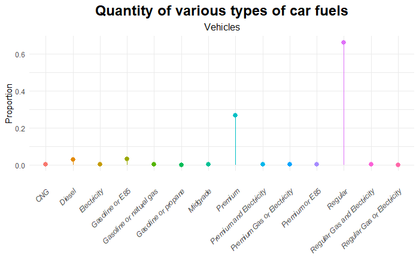

```r
P1.1 <- ggplot(vehicle1,aes(x = fuel_type, y = proportion, color = fuel_type)) +

        geom_pointrange(aes(ymin = 0, ymax = proportion)) +
        guides(color = FALSE) +

        labs(x = "", y = "Proportion", title = "Quantity of various types of car fuels", subtitle = "Vehicles") +
        theme_minimal() +
        theme(axis.text.x = element_text(angle = 45, vjust = 0.8, hjust=1, family="Courier", face="italic"),
              plot.title = element_text(size = 18, face = "bold", hjust = 0.5),
              plot.subtitle = element_text(size = 12, hjust = 0.5))
P1.1
```

```r
install.packages("svglite")
```

```r
library("svglite")
ggsave("Quantity of various types of car fuels.jpg", P1.1, width = 4, height = 4)
```

[output not shown]

**Comment**

As we see in this graph, the most common fuel type is “regular”. More than 60% of cars use this type of fuel. We normally know this fuel as “gasoline”.

I was specting this result since this is a common fuel, but I was also wondering about how far we are from renewable fuel.

For this first visualization, we just consider the “Fuel_type” column. There are other columns that need to be included, like “fuel_type_1”.

## How efficient is performance in cities and highways by fuel type?.

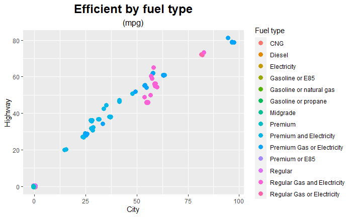

```r
P1.2 <- ggplot(vehicle, aes(composite_city_mpg, composite_highway_mpg, color = fuel_type)) +

        geom_jitter(width = .5, size=3) +

       labs(subtitle="(mpg)",
                   y="Highway",
                   x="City",
               title="Efficient by fuel type",
              color = "Fuel type") +
       theme(legend.position="right",
              plot.title = element_text(size = 18, face = "bold", hjust = 0.5),
              plot.subtitle = element_text(size = 12, hjust = 0.5))

P1.2
```

```r
ggsave("Efficient by fuel type.jpg", P1.2, width = 7, height = 4)
```

**Comment**

Along with efficiency, cost will be an important factor to consider. That may be a fascinating investigation.

## How fuels type have been implemented over time?

```
Warning in viridisLite::viridis(n, alpha, begin, end, direction, option) :
  Option 'm' does not exist. Defaulting to 'viridis'.
```

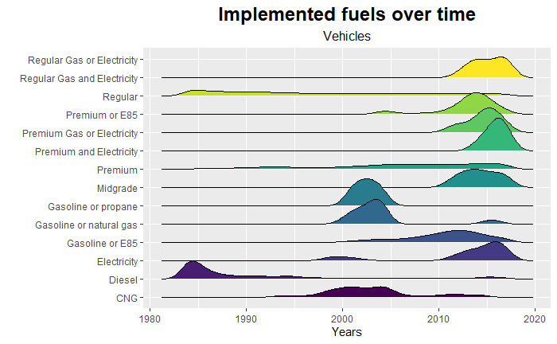

```r
library("ggridges")
P1.3 <- ggplot(vehicle, aes(x = year, y = fuel_type, fill = fuel_type)) +
  geom_density_ridges() +
  guides(fill = FALSE)+
  scale_fill_viridis_d(option = "m")+
  labs(y = "", x = "Years", title = "Implemented fuels over time", subtitle = "Vehicles")+
  theme(
        legend.position = "none",
        plot.title = element_text(size = 18, face = "bold", hjust = 0.5),
        plot.subtitle = element_text(size = 12, hjust = 0.5))
P1.3
```

```r
ggsave("Implemented fuels over time.jpg", P1.3, width = 7, height = 4)
```

```
Warning in viridisLite::viridis(n, alpha, begin, end, direction, option) :
  Option 'm' does not exist. Defaulting to 'viridis'.
```

**Comment**

It can be interesting to plot some historical data about this fuel introduction. In this plot, there is a decrease in regular fuel. Electric fuel or cars are getting more attention. This may be because of preview analysis about efficacy.